# Reproducible Research W2

Clemence Aristide

August 26, 2016

## Creating the dataset

```r
df<-read.csv("activity.csv")
head(df)
```

```
##   steps       date interval
## 1    NA 2012-10-01        0
## 2    NA 2012-10-01        5
## 3    NA 2012-10-01       10
## 4    NA 2012-10-01       15
## 5    NA 2012-10-01       20
## 6    NA 2012-10-01       25
```

```r
tail(df)
```

```
##       steps       date interval
## 17563    NA 2012-11-30     2330
## 17564    NA 2012-11-30     2335
## 17565    NA 2012-11-30     2340
## 17566    NA 2012-11-30     2345
## 17567    NA 2012-11-30     2350
## 17568    NA 2012-11-30     2355
```

```r
str(df)
```

```
## 'data.frame':    17568 obs. of  3 variables:
##  $ steps   : int  NA NA NA NA NA NA NA NA NA NA ...
##  $ date    : Factor w/ 61 levels "2012-10-01","2012-10-02",..: 1 1 1 1 1 1 1 1 1 1 ...
##  $ interval: int  0 5 10 15 20 25 30 35 40 45 ...
```

## Question 1: What is mean total number of steps taken per day?

### 1. Calculate the total number of steps taken per day

We will create a dataset with no na values, grouped by date, where steps are aggregrated by their sum.

First we load the dplyr package in order to use group_by.

```r
library(dplyr)
```

Then we create the dataset in two steps.

```r
df_complete<-df[!is.na(df$steps),]
bydate<- summarize(group_by(df_complete,date),steps=sum(steps))
```

### 2. Make a histogram of the total number of steps taken each day

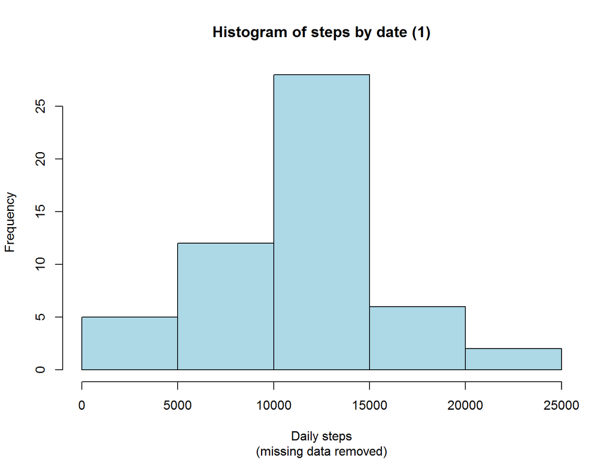

```r
hist(bydate$steps,col="light blue",xlab="Daily steps",main="Histogram of steps by date (1)",sub="(missing data removed)")
```

### 3.Calculate and report the mean and median of the total number of steps taken per day

First we calculate the mean and the median of the total number of steps taken per day. We store them as two values for later.

```r
daily_average<-mean(bydate$steps)
daily_median<-median(bydate$steps)
```

Then we display the results.

```r
daily_average
```

```
## [1] 10766.19
```

```r
daily_median
```

```
## [1] 10765
```

## Question 2: What is the average daily activity pattern?

### 1. Make a time series plot (i.e. type = “l”) of the 5-minute interval (x-axis) and the average number of steps taken, averaged across all days (y-axis)

First we create a dataset with no na values, grouped by interval, where steps are aggregated by their mean.

```r
byinterval<-summarize(group_by(df_complete,interval),steps=mean(steps))
```

Then we draw the line chart showing the average number of steps by interval.

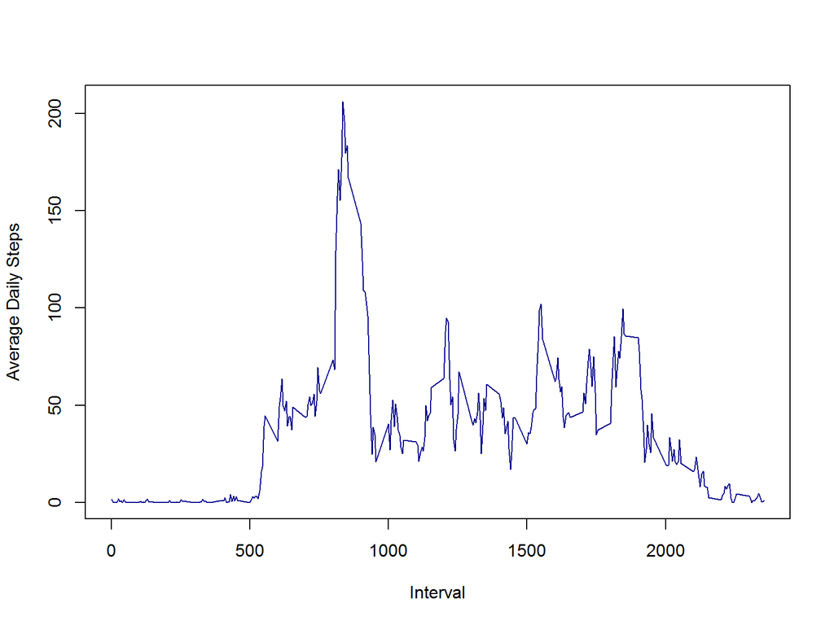

```r
plot(byinterval$interval,byinterval$steps,type="l",xlab="Interval",ylab="Average Daily Steps",col="dark blue")
```

### 2. Which 5-minute interval, on average across all the days in the dataset, contains the maximum number of steps?

In order to find this value, we use the which.max function.

```r
as.numeric(byinterval[which.max(byinterval$steps),1])
```

```
## [1] 835
```

## Question 3: Imputing missing values

### 1. Calculate and report the total number of missing values in the dataset (i.e. the total number of rows with NAs)

We use the colSums function to get a report on the number of null values per column.

```r
colSums(is.na(df))
```

```
##    steps     date interval
##     2304        0        0
```

### 2. Devise a strategy for filling in all of the missing values in the dataset. The strategy does not need to be sophisticated. For example, you could use the mean/median for that day, or the mean for that 5-minute interval, etc.

For each missing value in the dataset we are going to allocate the mean for that 5-minute interval.

### 3. Create a new dataset that is equal to the original dataset but with the missing data filled in.

First we create a dataset called df_na that contains only the row of df where the steps are missing. We check the number of missing values and the number of rows in the dataset to make sure they’re in line with the original dataset.

```r
df_na<-df[is.na(df$steps),]
colSums(is.na(df_na))
```

```
##    steps     date interval
##     2304        0        0
```

```r
nrow(df_na)
```

```
## [1] 2304
```

Then we are going to pull data from byinterval which is the dataset showing the average number of steps by interval.

For each row in df_na, we’re going to look for the steps value corresponding to the given interval in the byinterval dataset.

Then we check that there’s no null value anymore and that we still have the right number of rows.

```r
for (i in (1:nrow(df_na))) {
    df_na[i,1]=byinterval[which(byinterval$interval==df_na[i,3]),2]
}
colSums(is.na(df_na))
```

```
##    steps     date interval
##        0        0        0
```

```r
nrow(df_na)
```

```
## [1] 2304
```

In order to create the new dataset that is equal to the original dataset but with the missing data filled in dfnew, we’re going to combine df_na with all the non null rows in df. So we first create the set dfnotna that has no null values and we use rbind to combine both datasets.

Then we check that the number of rows corresponds to the number of rows in the original dataset.

```r
df_notna<-df[!is.na(df$steps),]
colSums(is.na(df_notna))
```

```
##    steps     date interval
##        0        0        0
```

```r
nrow(df_notna)
```

```
## [1] 15264
```

```r
nrow(df_na)+nrow(df_notna)==nrow(df)
```

```
## [1] TRUE
```

```r
df_new<-rbind(df_na,df_notna)
nrow(df_new)==nrow(df)
```

```
## [1] TRUE
```

### 4.Make a histogram of the total number of steps taken each day and Calculate and report the mean and median total number of steps taken per day. Do these values differ from the estimates from the first part of the assignment? What is the impact of imputing missing data on the estimates of the total daily number of steps?

We perform the same steps as in question 1 but we are using df_new instead of df.

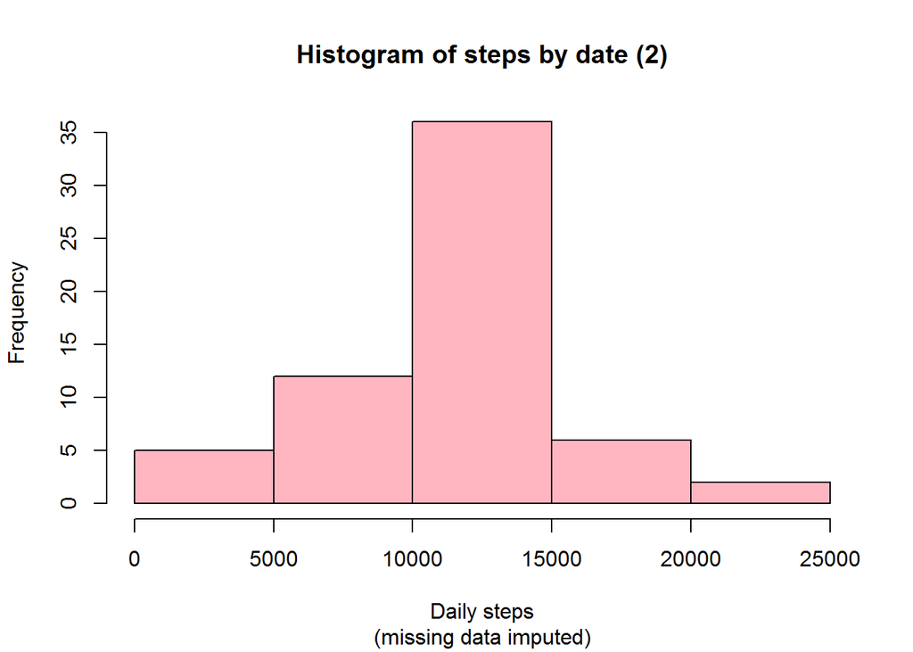

```r
bydate_new<- summarize(group_by(df_new,date),steps=sum(steps))
hist(bydate_new$steps,col="light pink",xlab="Daily steps",main="Histogram of steps by date (2)",sub="(missing data imputed)")
```

```r
daily_average_new<-mean(bydate_new$steps)
daily_median_new<-median(bydate_new$steps)

daily_average_new
```

```
## [1] 10766.19
```

```r
daily_median_new
```

```
## [1] 10766.19
```

Now we’re going to compare the results for both datasets.

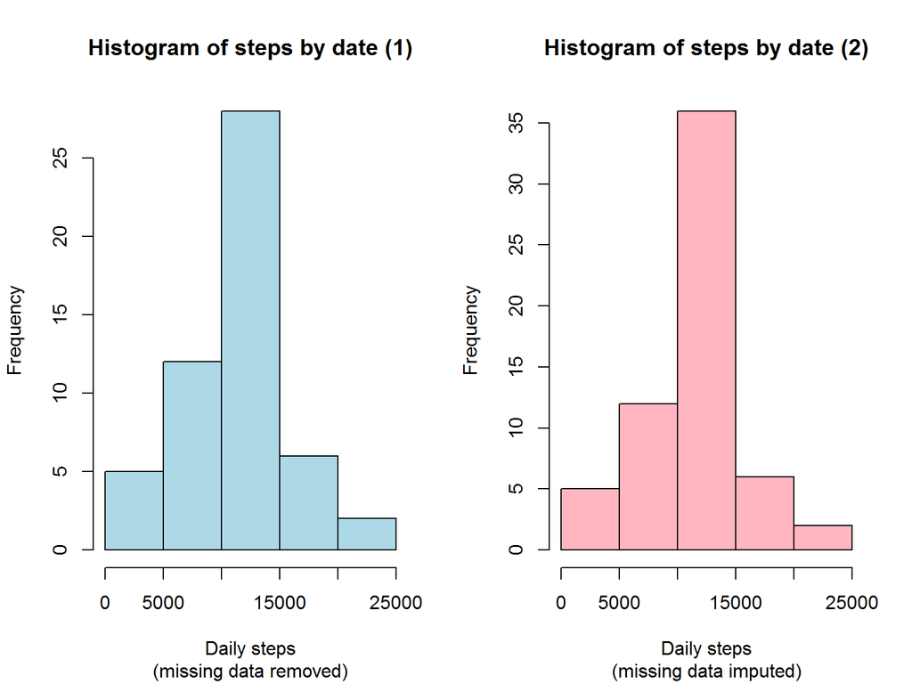

```r
par(mfrow=c(1,2))
hist(bydate$steps,col="light blue",xlab="Daily steps",main="Histogram of steps by date (1)",sub="(missing data removed)")
hist(bydate_new$steps,col="light pink",xlab="Daily steps",main="Histogram of steps by date (2)",sub="(missing data imputed)")
```

```r
daily_average-daily_average_new
```

```
## [1] 0
```

```r
daily_median-daily_median_new
```

```
## [1] -1.188679
```

The histograms look similar and the average is the same, so the estimate was accurate. However the median is impacted by the estimate since it is different from one dataset to the other.

## Question 4: Are there differences in activity patterns between weekdays and weekends?

For this part the weekdays() function may be of some help here. Use the dataset with the filled-in missing values for this part.

### 1. Create a new factor variable in the dataset with two levels - “weekday” and “weekend” indicating whether a given date is a weekday or weekend day.

```r
df_new$date<-as.Date(df_new$date)

df_new$weekday<-weekdays(df_new$date)
df_new$weekday<-as.factor(df_new$weekday)

df_new$date2<-"weekday"
df_new[which(df_new$weekday=="Sunday"|df_new$weekday=="Saturday"),5]<-"weekend"

head(df_new[which(df_new$weekday=="Sunday"|df_new$weekday=="Saturday"),],30)
```

```
##          steps       date interval weekday   date2
## 9793 1.7169811 2012-11-04        0  Sunday weekend
## 9794 0.3396226 2012-11-04        5  Sunday weekend
## 9795 0.1320755 2012-11-04       10  Sunday weekend
## 9796 0.1509434 2012-11-04       15  Sunday weekend
## 9797 0.0754717 2012-11-04       20  Sunday weekend
## 9798 2.0943396 2012-11-04       25  Sunday weekend
## 9799 0.5283019 2012-11-04       30  Sunday weekend
## 9800 0.8679245 2012-11-04       35  Sunday weekend
## 9801 0.0000000 2012-11-04       40  Sunday weekend
## 9802 1.4716981 2012-11-04       45  Sunday weekend
## 9803 0.3018868 2012-11-04       50  Sunday weekend
## 9804 0.1320755 2012-11-04       55  Sunday weekend
## 9805 0.3207547 2012-11-04      100  Sunday weekend
## 9806 0.6792453 2012-11-04      105  Sunday weekend
```

[output cut: 16 more lines]

```r
head(df_new[which(df_new$weekday!="Sunday"&df_new$weekday!="Saturday"),],30)
```

```
##        steps       date interval weekday   date2
## 1  1.7169811 2012-10-01        0  Monday weekday
## 2  0.3396226 2012-10-01        5  Monday weekday
## 3  0.1320755 2012-10-01       10  Monday weekday
## 4  0.1509434 2012-10-01       15  Monday weekday
## 5  0.0754717 2012-10-01       20  Monday weekday
## 6  2.0943396 2012-10-01       25  Monday weekday
## 7  0.5283019 2012-10-01       30  Monday weekday
## 8  0.8679245 2012-10-01       35  Monday weekday
## 9  0.0000000 2012-10-01       40  Monday weekday
## 10 1.4716981 2012-10-01       45  Monday weekday
## 11 0.3018868 2012-10-01       50  Monday weekday
## 12 0.1320755 2012-10-01       55  Monday weekday
## 13 0.3207547 2012-10-01      100  Monday weekday
## 14 0.6792453 2012-10-01      105  Monday weekday
```

[output cut: 16 more lines]

```r
df_new$date2<-as.factor(df_new$date2)
```

### 2. Make a panel plot containing a time series plot (i.e. type = “l”) of the 5-minute interval (x-axis) and the average number of steps taken, averaged across all weekday days or weekend days (y-axis). See the README file in the GitHub repository to see an example of what this plot should look like using simulated data.

```r
byinterval_new<-summarize(group_by(df_new,interval,date2),steps=mean(steps))

par(mfrow=c(1,1))
```

[figure not shown]

```r
library(lattice)
xyplot(steps~interval|date2,data=byinterval_new,type="l",layout=c(1,2),xlab = "Number of steps",ylab="Interval")
```